# Recomendador de Filmes

Movie Recommender: Collaborative Filtering, Shiny - IMDB - Internet Movie DataBases

Ewerson C. Pimenta

pimentaeu@yahoo.com

Marcos Antônio E. de Oliveira

marcoseuzbio@gmail.com

Rio de Janeiro, 08 de outubro de 2018

```r
ptm = proc.time()
```

# 1 Introdução

Frequentemente utilizamos serviços de recomendação seja por plataformas como *Netflix, Mercado Livre, OLX* dentre outros. O conjunto de dados explanados a seguir foram extraídos da plataforma Kaggle e são referentes ao catálogo de filmes da plataforma IMDB, o intuito aqui é criar um sistema de recomendação orientado a dados do catálogo e avaliação de filmes do IMDB.

Esse projeto irá explorar o conjunto de dados e gerar insights, e aplicar o algoritmo de Random Forest (baseado na clusterização de Breiman).

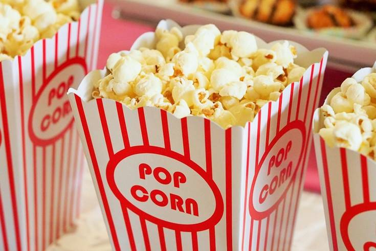

**Pacotes e Leitura**

Alguns pacotes R utilizados nessa rotina

```yaml
library(tidyverse)          # Manipulação de banco de dados e análise exploratória
library(highcharter)        # Highchart gráficos usando htmlwidgets (renderiza HTML via código R Markdown)
library(DT)                 # Tabelas: datatable()
library(knitr)
library(kableExtra)
library(rpart.plot)
library(randomForest)
```

```yaml
RECOMEND.METADATA = readxl::read_xlsx(path = ".../DB/IMDB.xlsx", sheet = 1)
db = RECOMEND.METADATA
```

# 2 Banco de Dados

|  | Variables | Description |
| --- | --- | --- |
| 1 | movie_title | Title of the Movie |
| 2 | duration | Duration in minutes |
| 3 | director_name | Name of the Director of the Movie |
| 4 | director_facebook_likes | Number of likes of the Director on his Facebook Page |
| 5 | actor_1_name | Primary actor starring in the movie |
| 6 | actor_1_facebook_likes | Number of likes of the Actor_1 on his/her Facebook Page |
| 7 | actor_2_name | Other actor starring in the movie |
| 8 | actor_2_facebook_likes | Number of likes of the Actor_2 on his/her Facebook Page |
| 9 | actor_3_name | Other actor starring in the movie |
| 10 | actor_3_facebook_likes | Number of likes of the Actor_3 on his/her Facebook Page |

[output cut: 18 more lines]

*Os dados em questão são públicos e disponíveis para download clicando [AQUI](https://data.world/data-society/imdb-5000-movie-dataset) ou [AQUI](https://www.kaggle.com/carolzhangdc/analyze-imdb-score-with-data-mining-algorithms/data).*

# 3 Análise Exploratória dos dados

| color | director_name | num_critic_for_reviews | duration | director_facebook_likes | actor_3_facebook_likes | actor_2_name | actor_1_facebook_likes | gross | genres | actor_1_name | movie_title | num_voted_users | cast_total_facebook_likes | actor_3_name | facenumber_in_poster | plot_keywords | movie_imdb_link | num_user_for_reviews | language | country | content_rating | budget | title_year | actor_2_facebook_likes | imdb_score | aspect_ratio | movie_facebook_likes |
| --- | --- | --- | --- | --- | --- | --- | --- | --- | --- | --- | --- | --- | --- | --- | --- | --- | --- | --- | --- | --- | --- | --- | --- | --- | --- | --- | --- |
| Color | Jem Cohen | 12 | 111 | 6 |  |  |  |  | Documentary |  | Counting | 61 | 0 |  | 0 | city\|city symphony\|diary\|essay\|surveillance | http://www.imdb.com/title/tt4462082/?ref_=fn_tt_tt_1 | 1 | English | USA |  | 50000 | 2015 |  | 6.0 | 1.78 | 5 |
| Color | Paul Schrader | 75 | 106 | 261 | 520 | Ayelet Zurer | 30000 |  | Drama\|War | Veronica Ferres | Adam Resurrected | 3075 | 31325 | Derek Jacobi | 2 | circus\|dog\|entertainer\|holocaust\|patient | http://www.imdb.com/title/tt0479341/?ref_=fn_tt_tt_1 | 31 | English | Germany | R | 10000000 | 2008 | 744 | 6.3 | 2.35 | 589 |
| Color | Frederik Du Chau | 73 | 102 | 7 | 521 | Frankie Muniz | 984 | 49186871 | Adventure\|Comedy\|Drama\|Family\|Sport | Bruce Greenwood | Racing Stripes | 12570 | 2910 | M. Emmet Walsh | 0 | farm\|horse\|kentucky\|racehorse\|zebra | http://www.imdb.com/title/tt0376105/?ref_=fn_tt_tt_1 | 86 | English | USA | PG |  | 2005 | 934 | 5.2 | 1.85 | 771 |
| Color | Robert Luketic | 174 | 96 | 126 | 954 | John Michael Higgins | 18000 | 88915214 | Comedy\|Romance | Gerard Butler | The Ugly Truth | 163665 | 22436 | Eric Winter | 2 | call in\|chick flick\|date\|hot air balloon\|show producer | http://www.imdb.com/title/tt1142988/?ref_=fn_tt_tt_1 | 169 | English | USA | R | 38000000 | 2009 | 957 | 6.5 | 2.35 | 9000 |
| Color |  | 4 | 60 |  | 398 | Brittany Curran | 629 |  | Drama\|Mystery\|Thriller | Grey Damon | Twisted | 7945 | 2758 | Aaron Hill | 2 |  | http://www.imdb.com/title/tt2355844/?ref_=fn_tt_tt_1 | 22 | English | USA |  |  |  | 512 | 7.5 | 16.0 | 915 |
| Color | Annabel Jankel | 36 | 104 | 5 | 687 | Fisher Stevens | 5000 | 20915465 | Adventure\|Comedy\|Family\|Fantasy\|Sci-Fi | Bob Hoskins | Super Mario Bros. | 38203 | 7723 | Fiona Shaw | 0 | based on video game\|dinosaur\|king\|mario\|plumber | http://www.imdb.com/title/tt0108255/?ref_=fn_tt_tt_1 | 290 | English | UK | PG | 42000000 | 1993 | 922 | 4.0 | 1.85 | 0 |
| Color | Dennis Dugan | 179 | 102 | 221 | 4000 | Adam Sandler | 12000 | 162001186 | Comedy | Steve Buscemi | Grown Ups | 181443 | 28497 | Salma Hayek | 4 | basketball\|coach\|daughter\|high school\|high school basketball | http://www.imdb.com/title/tt1375670/?ref_=fn_tt_tt_1 | 311 | English | USA | PG-13 | 80000000 | 2010 | 11000 | 6.0 | 1.85 | 12000 |
| Color | Nelson McCormick | 146 | 89 | 29 | 458 | Scott Porter | 2000 | 43818159 | Horror\|Mystery | Ming-Na Wen | Prom Night | 27664 | 4867 | Collins Pennie | 0 | friend\|hotel\|killer\|murder\|prom | http://www.imdb.com/title/tt0926129/?ref_=fn_tt_tt_1 | 260 | English | USA | PG-13 | 20000000 | 2008 | 690 | 3.9 | 2.35 | 1000 |
| Color | Robert Stevenson | 145 | 139 | 55 | 266 | Glynis Johns | 382 | 102300000 | Comedy\|Family\|Fantasy\|Musical | Ed Wynn | Mary Poppins | 107408 | 2045 | Elsa Lanchester | 2 | banker\|female protagonist\|live action and animation\|magic\|nanny | http://www.imdb.com/title/tt0058331/?ref_=fn_tt_tt_1 | 259 | English | USA | Approved | 6000000 | 1964 | 279 | 7.8 | 1.66 | 0 |
| Color | Niki Caro | 149 | 101 | 51 | 8 | Rawiri Paratene | 446 | 20772796 | Drama\|Family | Keisha Castle-Hughes | Whale Rider | 34232 | 497 | Tammy Davis | 1 | girl\|maori\|new zealand\|tradition\|whale | http://www.imdb.com/title/tt0298228/?ref_=fn_tt_tt_1 | 346 | English | New Zealand | PG-13 | 6000000 | 2002 | 20 | 7.6 | 2.35 | 0 |

[output cut: 25 more lines]

## 3.1 Estrutura dos dados

```
## O banco de dados possui 5043 observações e 28 variáveis
```

Excluindo algumas variáveis que não serão utilizadas.

- 1. As variáveis *color*, *director_name*, *language*, *country*, *content_rating*, em especial, foram removidas uma vez que estas não se mostraram importantes no algoritmo de importância do Random Forest de Breiman.
- 2. Já as variáveis *director_facebook_likes*, *actor_3_facebook_likes*, *actor_2_name*, *actor_1_facebook_likes*, *actor_1_name*, *actor_3_name,-facenumber_in_poster*, *actor_2_facebook_likes*, *movie_imdb_link* foram extraídas de forma determinística por escolha dos autores deste.

```r
#db=RECOMMEND.METADATA
db = db %>% select(- director_facebook_likes, -actor_3_facebook_likes, -actor_2_name, -actor_1_facebook_likes, -actor_1_name, -actor_3_name,-facenumber_in_poster, -actor_2_facebook_likes, -color, -director_name, -language, -country, -content_rating, -movie_imdb_link)
```

```
## O banco de dados agora possui 14 variáveis. Ou seja, foram removidas  14 variáveis no passo anterior.
```

Estrutura dos dados

```r
glimpse(db) #str(db)
```

```
## Observations: 5,043
## Variables: 14
## $ num_critic_for_reviews    <int> 723, 302, 602, 813, NA, 462, 392, 32...
## $ duration                  <int> 178, 169, 148, 164, NA, 132, 156, 10...
## $ gross                     <int> 760505847, 309404152, 200074175, 448...
## $ genres                    <fct> Action|Adventure|Fantasy|Sci-Fi, Act...
## $ movie_title               <fct> Avatar , Pirates of the Caribbean: A...
## $ num_voted_users           <int> 886204, 471220, 275868, 1144337, 8, ...
## $ cast_total_facebook_likes <int> 4834, 48350, 11700, 106759, 143, 187...
## $ plot_keywords             <fct> avatar|future|marine|native|parapleg...
## $ num_user_for_reviews      <int> 3054, 1238, 994, 2701, NA, 738, 1902...
## $ budget                    <dbl> 237000000, 300000000, 245000000, 250...
## $ title_year                <int> 2009, 2007, 2015, 2012, NA, 2012, 20...
## $ imdb_score                <fct> 7.9, 7.1, 6.8, 8.5, 7.1, 6.6, 6.2, 7...
## $ aspect_ratio              <fct> 1.78, 2.35, 2.35, 2.35, , 2.35, 2.35...
## $ movie_facebook_likes      <int> 33000, 0, 85000, 164000, 0, 24000, 0...
```

## 3.2 Transformação de variáveis

Transformando as variáveis `imdb_score` e `aspect_ratio` em numéricas

```r
db$imdb_score = as.numeric(as.character(db$imdb_score))
db$aspect_ratio = as.numeric(as.character(db$aspect_ratio))
```

```r
hc1 = hchart(db$imdb_score, color = "#e8bb0b", name = "imdb_score") %>%
        hc_title(text = "Histograma dos votos na plataforma IMDB") %>%
        hc_exporting(enabled = TRUE, filename = "Fig1-Pimenta"); hc1
```

[interactive chart not shown]

```r
hc2 = hchart(db$num_voted_users, color = "#786eea", name = "imdb_num_votos") %>%
        hc_title(text = "Histograma dos número de votos na plataforma IMDB") %>%
        hc_exporting(enabled = TRUE, filename = "Fig2-Pimenta"); hc2
```

[interactive chart not shown]

Criando uma função para cálculo da moda

```r
Moda <- function(x) {
     ux <- unique(x)
     ux[which.max(tabulate(match(x, ux)))]
}
```

```
## Média, moda e mediana da variável imdb_score são, respectivamente, 6.44 6.7 6.6
```

Extraindo valores da variável gênero e transformando em dummies

```r
gg <- as.character(db$genres)

#t <- unlist(strsplit(gg[1],split = "\\|"))
tem1 <- data.frame()
for(i in 1:length(gg)){
        tem <- tem1
        t <- unlist(strsplit(gg[i],split = "\\|"))
        temp <- data.frame(t)
        tem1 <- rbind(tem,temp)
}

Gen <- unique(tem1)
cat("Existem", dim(Gen)[1], "valores de gêneros de filme únicos no banco de dados.")
```

```
## Existem 26 valores de gêneros de filme únicos no banco de dados.
```

```r
Genname <- as.character(Gen$t); Genname = gsub("-", "_", Genname)

fe <- matrix(data = 0, nrow = length(gg), ncol = length(Genname))
fe <- data.frame(fe); colnames(fe) <- Genname

for(i in 1:length(gg)){
        for(j in 1:length(Genname)){
                g <- grepl(Genname[j], gg[i])
                if(g == TRUE){
                        fe[i, j] <- 1
                }
        }
}

NumGen = as_tibble(rbind(apply(fe,2,sum)))
NumGen = gather(NumGen, key = "variables", value = "num_gender")
NumGen = NumGen[order(NumGen$num_gender, decreasing = TRUE), ]


hc3 <- highchart() %>%
  hc_add_series(data = NumGen$num_gender,
                type = "bar",
                name = "# de filmes",
                showInLegend = FALSE,
                tooltip = list(valueDecimals = 0, valuePrefix = "", valueSuffix = ""), color="blue") %>%
  hc_yAxis(title = list(text = "Quantitativo de filmes"),
           allowDecimals = TRUE, max = (max(NumGen$num_gender)+103),
           labels = list(format = "{value}")) %>%
  hc_xAxis(title = list(text = "Gênero de filme"),
           categories = NumGen$variables,
           tickmarkPlacement = "on",
           opposite = FALSE) %>%
  hc_title(text = "Quantitativo de filmes por gênero",
           style = list(fontWeight = "bold")) %>%
  hc_subtitle(text = paste("")) %>%
      hc_tooltip(valueDecimals = 2,
                 pointFormat = "{point.y} filmes")%>%
                 #pointFormat = "Variável: {point.x} <br> Missing: {point.y}")
      hc_credits(enabled = TRUE,
                 text = "Fonte: IMDB/KAGGLE. Elaboração: Ewerson Pimenta.",
                 style = list(fontSize = "10px")) %>%
  hc_exporting(enabled = TRUE, filename = "F3-filmes-genero-Pimenta")
#hc <- hc %>%
#  hc_add_theme(hc_theme_darkunica())
hc3; remove(gg,t,tem, temp, tem1,Gen, g, i, j)
```

[interactive chart not shown]

Unificando a base de dados com as novas variáveis de gêneros únicos descobertos.

```r
db1 = as_tibble(cbind(as.data.frame(db),fe))
```

```r
cat("Foram inseridas todas as", dim(fe)[2],"novas variáveis provenientes dos gêneros únicos descobertos no passo anterior.")
```

```
## Foram inseridas todas as 26 novas variáveis provenientes dos gêneros únicos descobertos no passo anterior.
```

Semelhante à variável de gênero, foi feito o split por palavra chave da variável keyword e, posteriormente, geramos uma nuvem de palavras chave contidas na base de dados, com o auxílio do pacote `wordcloud2`. Esse, por sua vez continha 6780 palavras únicas.

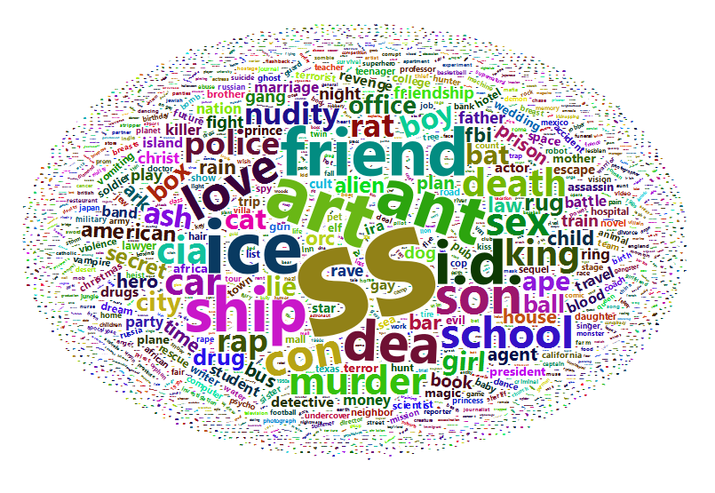

## 3.3 Tratamento de NA

Porcentagem de NA por variável

```r
db_miss <- db %>% summarise_all(funs(sum(is.na(.))/n()))
```

```r
db_miss <- gather(db_miss, key = "variables", value = "percent_missing")
db_miss$percent_missing = 100*db_miss$percent_missing
db_miss = db_miss[order(db_miss$percent_missing, decreasing = TRUE), ]
#db_miss

hc4 <- highchart() %>%
  hc_add_series(data = db_miss$percent_missing,
                type = "bar",
                name = "Porcentagem de missing",
                showInLegend = FALSE,
                tooltip = list(valueDecimals = 2, valuePrefix = "", valueSuffix = " %")) %>%
  hc_yAxis(title = list(text = "Porcentagem de missing"),
           allowDecimals = TRUE, max = 20,
           labels = list(format = "{value}%")) %>%
  hc_xAxis(categories = db_miss$variables,
           tickmarkPlacement = "on",
           opposite = FALSE) %>%
  hc_title(text = "Porcentagem de missinig por variável",
           style = list(fontWeight = "bold")) %>%
  hc_subtitle(text = paste("")) %>%
      hc_tooltip(valueDecimals = 2,
                 pointFormat = "Missing: {point.y}")%>%
                 #pointFormat = "Variável: {point.x} <br> Missing: {point.y}")
      hc_credits(enabled = TRUE,
                 text = "Fonte: IMDB/KAGGLE. Elaboração: Ewerson Pimenta.",
                 style = list(fontSize = "10px")) %>%
  hc_exporting(enabled = TRUE, filename = "Fig0-Pimenta")
#hc <- hc %>%
#  hc_add_theme(hc_theme_darkunica())
hc4
```

[interactive chart not shown]

Removendo todas as observações que contêm NA.

```r
db1 <- db1 %>% drop_na(gross, budget, aspect_ratio
,title_year
,num_critic_for_reviews, num_user_for_reviews)
#glimpse(db1)

db1 <- db1 %>% na.omit()
db1 <- db1 %>% drop_na()
```

```
## O novo banco de dados, sem observações faltantes, possui 3815 observações. Ou seja, no processo de remoção de valores faltantes foram perdidas 1228 observações.
```

## 3.4 Weighted Rating (WR) - IMDB_score

Um passo importante é penalizar a variável de escore `imdb_score` pelo [número de votos recebidos](https://help.imdb.com/article/imdb/track-movies-tv/faq-for-imdb-ratings/G67Y87TFYYP6TWAV#). Ver mais no estimador de [Shrinkage](https://stats.stackexchange.com/questions/6418/rating-system-taking-account-of-number-of-votes)

$WR = \frac{v}{v+m} \times R + \frac{m}{v+m} \times C$

Onde,

```r
R = as.numeric(db1$imdb_score)
v = as.numeric(db1$num_voted_users)
m = 7000
C = 6.5
db1$WR = (v/(v+m))*R + (m/(v+m))*C
```

```r
summary(db1$imdb_score)
```

```
##    Min. 1st Qu.  Median    Mean 3rd Qu.    Max.
##   1.600   5.900   6.600   6.467   7.200   9.300
```

```r
summary(db1$WR)
```

```
##    Min. 1st Qu.  Median    Mean 3rd Qu.    Max.
##   2.022   6.057   6.544   6.547   7.080   9.288
```

```r
sd(db1$imdb_score)
```

```
## [1] 1.056944
```

```r
sd(db1$WR)
```

```
## [1] 0.8485412
```

Selecionando uma amostra aleatória (a.a.) de tamanho $n=800$ e representando em um gráfico de dispersão com valores reais vs ajustados.

```r
set.seed(123654)
amostra0 = sample(x = 1:dim(db1)[1], size = 800, replace = FALSE)
dbX = db1[amostra0,] %>%
  select(movie_title,num_voted_users,imdb_score, WR)

dss <- map(c("cross"), function(s){

  x <- as.numeric(dbX$imdb_score)
  y <- as.numeric(dbX$WR)

  list(name = s,
       data = list_parse(data_frame(x, y)),
       marker = list(symbol = s, enabled = TRUE), lineColor = "#56667a")

})
#dss[[1]]$data[amostra1]

hc5 = highchart() %>%
  hc_chart(type = "scatter", color = "#56667a") %>%
  hc_title(text = "Score IMDB vs WR (calculado pelo estimador de Shrinkage)") %>%
  hc_subtitle(text = "800 filmes selecionados via amostra aleatória simples") %>%
  hc_xAxis(title = list(text = "x: imdb_score"),
           allowDecimals = TRUE, labels = list(format = "{value}★")) %>%
  hc_yAxis(title = list(text = "y: WR (calibrado)"),
           allowDecimals = TRUE, labels = list(format = "{value}★")) %>%
  hc_exporting(enabled = TRUE, filename = "F3-Pimenta") %>%
  hc_add_series_list(dss); hc5; remove(dbX, dss)
```

[interactive chart not shown]

Análise do cálculo de IMDB

- Para filmes com # de votos recebidos MENOR que 7mil (m: votos mínimos requeridos):
  - imdb_score > 6,5: DECRESCIMENTO
  - imdb_score < 6,5: CRESCIMENTO
- Para filmes com # de votos recebidos MAIOR que 7mil (m: votos mínimos requeridos):
  - imdb_score > 6,5: DECRESCIMENTO
  - imdb_score < 6,5: CRESCIMENTO

Ou seja, para os filmes catalogados com m muito inferior a 7mil o novo escore calibrado teve maior diferentça que aqueles superior a 7 mil. Além disso, quando scores são maiores que 6,5 o WR tende a cair, caso contrário o valor pode aumentar. Quanto maior o número de votos recebidos, menor a diferença do valor de IMDB_score e WR.

```r
set.seed(123654)
amostra2 = sample(x = 1:dim(db1)[1], size = 35, replace = FALSE)
db1[amostra2,] %>%
  select(movie_title,num_voted_users,imdb_score, WR, movie_facebook_likes, budget) %>%
  datatable(rownames = amostra2,options = list(searchin = TRUE, scrollX = TRUE, pageLength = 5))
```

| movie_title | num_voted_users | imdb_score | WR | movie_facebook_likes | budget |
| --- | --- | --- | --- | --- | --- |
| Ouija | 31915 | 4.4 | 4.77774637029423 | 18000 | 5000000 |
| The Matrix | 1217752 | 8.7 | 8.68742602584033 | 25000 | 63000000 |
| Syriana | 109191 | 7 | 6.9698771849799 | 0 | 50000000 |
| Black Rain | 39306 | 6.6 | 6.58488316848788 | 0 | 30000000 |
| Thunderball | 82073 | 7 | 6.96070638689614 | 0 | 9000000 |
| The Right Stuff | 45271 | 7.9 | 7.71251554399189 | 0 | 27000000 |
| Miss Congeniality | 137377 | 6.2 | 6.21454525305277 | 0 | 45000000 |
| The Way of the Gun | 27536 | 6.7 | 6.65946258976141 | 1000 | 8500000 |
| Tropic Thunder | 307539 | 7 | 6.9888726040332 | 0 | 92000000 |
| The Believer | 30314 | 7.2 | 7.06868199603366 | 0 | 1500000 |

[output cut: 25 more lines]

## 3.5 Visualizações Finais

Finalmente, segue uma a.a.da base de dados após limpeza e análise exploratória.

```r
set.seed(123851)
amostra3 = sample(x = 1:dim(db1)[1], size = 35, replace = FALSE)
db1[amostra3,] %>%
datatable(rownames = amostra3,options = list(searchin = TRUE, scrollX = TRUE, pageLength = 5))
```

| num_critic_for_reviews | duration | gross | genres | movie_title | num_voted_users | cast_total_facebook_likes | plot_keywords | num_user_for_reviews | budget | title_year | imdb_score | aspect_ratio | movie_facebook_likes | Action | Adventure | Fantasy | Sci_Fi | Thriller | Documentary | Romance | Animation | Comedy | Family | Musical | Mystery | Western | Drama | History | Sport | … |
| --- | --- | --- | --- | --- | --- | --- | --- | --- | --- | --- | --- | --- | --- | --- | --- | --- | --- | --- | --- | --- | --- | --- | --- | --- | --- | --- | --- | --- | --- | --- |
| 117 | 147 | 41954997 | Biography\|Crime\|Drama | Donnie Brasco | 225122 | 56014 | fbi\|mafia\|money\|racial slur\|singer | 234 | 35000000 | 1997 | 7.8 | 2.35 | 0 | 0 | 0 | 0 | 0 | 0 | 0 | 0 | 0 | 0 | 0 | 0 | 0 | 0 | 1 | 0 | 0 | … |
| 76 | 89 | 38536376 | Action\|Adventure\|Comedy\|Family\|Sci-Fi | Spy Kids: All the Time in the World in 4D | 15866 | 4311 | 2010s\|3 dimensional\|breath holding contest\|child spy\|spy | 83 | 27000000 | 2011 | 3.6 | 1.85 | 0 | 1 | 1 | 0 | 0 | 0 | 0 | 0 | 0 | 1 | 1 | 0 | 0 | 0 | 0 | 0 | 0 | … |
| 106 | 137 | 22406362 | Drama\|History\|War\|Western | The Alamo | 16832 | 5780 | army\|dictator\|general\|texan\|texas | 267 | 107000000 | 2004 | 6 | 2.35 | 701 | 0 | 0 | 0 | 0 | 0 | 0 | 0 | 0 | 0 | 0 | 0 | 0 | 1 | 1 | 1 | 0 | … |
| 39 | 119 | 92115211 | Crime\|Drama\|Mystery\|Thriller | The Client | 45798 | 4043 | boy\|brother\|lawyer\|mafia\|senator | 94 | 45000000 | 1994 | 6.7 | 2.35 | 1000 | 0 | 0 | 0 | 0 | 1 | 0 | 0 | 0 | 0 | 0 | 0 | 1 | 0 | 1 | 0 | 0 | … |
| 225 | 115 | 144795350 | Action\|Mystery\|Sci-Fi\|Thriller | I, Robot | 387632 | 12068 | humanoid robot\|man versus machine\|prosthetic limb\|robot as pathos\|robot vs. robot | 789 | 120000000 | 2004 | 7.1 | 2.35 | 0 | 1 | 0 | 0 | 0 | 1 | 0 | 0 | 0 | 0 | 0 | 0 | 1 | 0 | 0 | 0 | 0 | … |
| 100 | 103 | 1530535 | Comedy\|Drama\|Romance | Trust the Man | 7833 | 1721 | actress\|lesbianism\|manhattan new york city\|urination\|watching pornography | 63 | 9000000 | 2005 | 5.7 | 2.35 | 215 | 0 | 0 | 0 | 0 | 0 | 0 | 1 | 0 | 1 | 0 | 0 | 0 | 0 | 1 | 0 | 0 | … |
| 91 | 138 | 10269307 | Action\|Crime\|Thriller | The Boondock Saints II: All Saints Day | 53251 | 17524 | final showdown\|ireland\|justice\|priest\|sheep | 188 | 8000000 | 2009 | 6.3 | 2.35 | 0 | 1 | 0 | 0 | 0 | 1 | 0 | 0 | 0 | 0 | 0 | 0 | 0 | 0 | 0 | 0 | 0 | … |
| 39 | 98 | 296665 | Biography\|Crime\|Drama\|Thriller | Party Monster | 12675 | 5185 | drug dealer\|drugs\|gay\|homosexual\|party | 158 | 5000000 | 2003 | 6.3 | 1.85 | 0 | 0 | 0 | 0 | 0 | 1 | 0 | 0 | 0 | 0 | 0 | 0 | 0 | 0 | 1 | 0 | 0 | … |
| 96 | 128 | 95860116 | Comedy\|Drama | Dead Poets Society | 277451 | 51609 | education\|english teacher\|poet\|professor\|student | 491 | 16400000 | 1989 | 8 | 1.85 | 23000 | 0 | 0 | 0 | 0 | 0 | 0 | 0 | 0 | 1 | 0 | 0 | 0 | 0 | 1 | 0 | 0 | … |
| 161 | 107 | 36279230 | Action\|Crime\|Thriller | The Sentinel | 42144 | 1352 | first lady\|framed\|investigation\|president\|secret service | 213 | 60000000 | 2006 | 6.1 | 2.35 | 690 | 1 | 0 | 0 | 0 | 1 | 0 | 0 | 0 | 0 | 0 | 0 | 0 | 0 | 0 | 0 | 0 | … |

[output cut: 25 more lines]

Para os dados quantitativos a seguinte [Matriz de correlação](https://cran.r-project.org/web/packages/corrplot/vignettes/corrplot-intro.html)

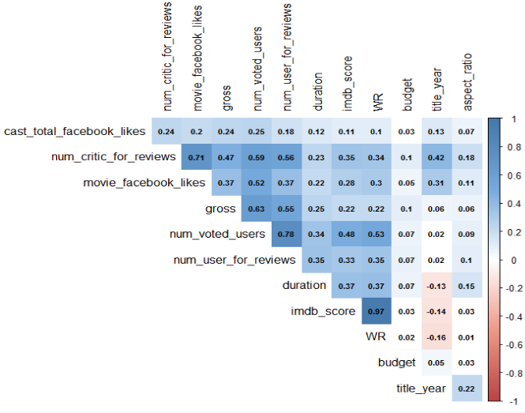

# 4 Modelagem

## 4.1 Preparação de dados

**Transformação da variável contínua `WR`em categórica `WR_Grp`**

Transformando a variável WR em fator, com as seguintes categorias:

- 0 a 4 ★
- de 4 a 6 ★
- de 6 a 8 ★
- de 8 a 10 ★

```r
movie = db1
Grp <- function(tn){
  tn = abs(tn)
    if (tn >= 0 & tn <= 4){
        return('de 0 a 4')
    }else if(tn > 4 & tn <= 6){
        return('de 4 a 6')
    }else if(tn > 6 & tn <= 8){
        return('de 6 a 8')
    }else if (tn > 8){
        return('de 8 a 10')
    }
}
# apply the Group function to the WR column
movie$WR_Grp <- sapply(movie$WR,Grp)
# set as factor the new column
movie$WR_Grp <- as.factor(movie$WR_Grp)
#View(head(movie))
table(movie$WR_Grp)
```

```
##
##  de 0 a 4  de 4 a 6  de 6 a 8 de 8 a 10
##        30       838      2797       150
```

```r
# apply the Group function to the WR column
imdb_score_Grp <- sapply(movie$imdb_score,Grp)
# set as factor the new column
imdb_score_Grp <- as.factor(imdb_score_Grp)
#View(head(movie))
table(imdb_score_Grp)
```

```
## imdb_score_Grp
##  de 0 a 4  de 4 a 6  de 6 a 8 de 8 a 10
##        94      1065      2496       160
```

**Remoção de variáveis** Remove as variáveis *imdb_score*, *genres*, *plot_keywords*, *movie_imdb_link* e *WR*.

```r
movie$imdb_score <- NULL
movie$genres <- NULL
movie$plot_keywords <- NULL
movie$movie_imdb_link <- NULL
movie$WR <- NULL
```

```r
glimpse(movie)
```

```
## Observations: 3,815
## Variables: 38
## $ num_critic_for_reviews    <int> 723, 302, 602, 813, 462, 392, 324, 6...
## $ duration                  <int> 178, 169, 148, 164, 132, 156, 100, 1...
## $ gross                     <int> 760505847, 309404152, 200074175, 448...
## $ movie_title               <fct> Avatar , Pirates of the Caribbean: A...
## $ num_voted_users           <int> 886204, 471220, 275868, 1144337, 212...
## $ cast_total_facebook_likes <int> 4834, 48350, 11700, 106759, 1873, 46...
## $ num_user_for_reviews      <int> 3054, 1238, 994, 2701, 738, 1902, 38...
## $ budget                    <dbl> 237000000, 300000000, 245000000, 250...
## $ title_year                <int> 2009, 2007, 2015, 2012, 2012, 2007, ...
## $ aspect_ratio              <dbl> 1.78, 2.35, 2.35, 2.35, 2.35, 2.35, ...
## $ movie_facebook_likes      <int> 33000, 0, 85000, 164000, 24000, 0, 2...
## $ Action                    <dbl> 1, 1, 1, 1, 1, 1, 0, 1, 0, 1, 1, 1, ...
## $ Adventure                 <dbl> 1, 1, 1, 0, 1, 1, 1, 1, 1, 1, 1, 1, ...
```

[output cut: 25 more lines]

```r
cat("A base de dados que iremos trabalhar no modelo tem", dim(movie)[1] , "observações e ", dim(movie)[2]-1, "variáveis, sem contar a variável que contém os títulos dos filmes.")
```

```
## A base de dados que iremos trabalhar no modelo tem 3815 observações e  37 variáveis, sem contar a variável que contém os títulos dos filmes.
```

**Partição dos dados**

Particionando a base de dados em Treino e Teste, esses dois (Treino e Teste) também terão armazenos os nomes dos filmes selecionados via amostragem probabilística dos dados originais separadamente das bases de Treino e Teste.

Posteriormente, removemos os rótulos dos filmes nas bases Treino e Teste

```r
set.seed(9182345)
ind <- sample(2, nrow(movie), replace = T, prob = c(0.7, 0.3))
train <- movie[ind==1, -4]
test <- movie[ind==2, -4]
trainMovie <- movie[ind==1, 4]
testMovie <- movie[ind==2, 4]
```

Distribuição dos escores nas bases de treino e teste

```r
round(table(train$WR_Grp)/sum(table(train$WR_Grp))*100,2)
```

```
##
##  de 0 a 4  de 4 a 6  de 6 a 8 de 8 a 10
##      0.63     22.21     73.31      3.85
```

```r
round(table(test$WR_Grp)/sum(table(test$WR_Grp))*100,2)
```

```
##
##  de 0 a 4  de 4 a 6  de 6 a 8 de 8 a 10
##      1.17     21.36     73.34      4.13
```

## 4.2 Random Forest - Metodologia

**Descrição** - Random Forest foi desenvolvido para agregar árvores de decisão (modelo de classificação);  
- Pode ser usado para modelo de classificação (p/ var. resposta categórica) ou regressão (no caso de haver variável resposta contínua);  
- Evita *overfitting*;  
- Permite trabalhar com um largo número de características de um conjunto de dados;  
- Auxilia na seleção de variáveis baseada em um algoritmo que calcula a importância por variável (assim, tendo conhecimento de quais variáveis são mais importantes, podemos usar essa informação para outros modelos de classificação);  
- User-friendly: apenas 2 parâmetros livres:  
+ Trees - ntrees, default 500 (Nº de árvores); + Variáveis selecionadas via amostragem aleatória candidatas à cada “split” (quebra da árvore) - mtry, default $\sqrt{p}$ p/ classificação e $\frac{p}{3}$ p/ regressão (p: nº de features/variáveis);

**Passo-a-Passo**

É realizado em 3 passos:

- 1. Draw ntrees bootstrap samples;
- 2. Para cada amostra via bootstrap, it grows un-puned tree by escolha da melhor quebra da árvore baseado na amostra aleatória do valor predito de mtry a cada nó da árvore;
- 3. Faz classificação de novos valores usando a maioria de votos p/ classificação e usa a média p/ regressão baseada nas amostras de ntrees.

**Exemplo**

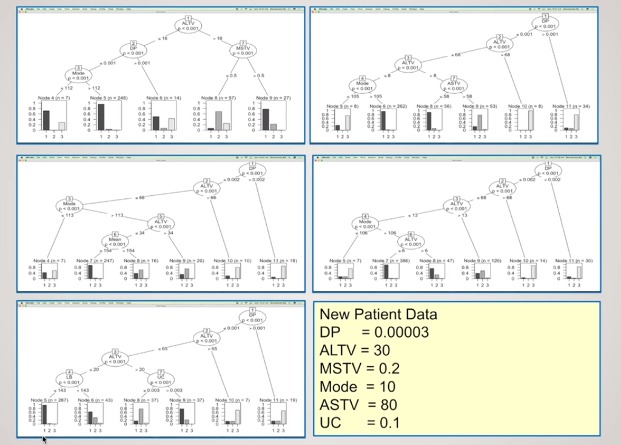

## 4.3 Random Forest - Aplicação

Inicialmente utilizaremos o pacote `randomForest` que implmenta o algoritmo de Random Forest de Breiman (baseado na clusterização de Breiman, originalmente codificada em Fortran) que tem por finalidade classificar e/ou criar regressão. Além disso, pode ser usado em um modelo não supervisionado para avaliar proximidades entre pontos.

Estamos usando, a partir daqui, a base de treino.

```r
#library(randomForest)
#library(rpart)
#library(rpart.plot)
#rf <- randomForest(proximity = T,ntree = 38,do.trace = T,WR~.,data=training)
set.seed(9984512)
rf <- randomForest(WR_Grp~.,data=train)
rf
```

```
##
## Call:
##  randomForest(formula = WR_Grp ~ ., data = train)
##                Type of random forest: classification
##                      Number of trees: 500
## No. of variables tried at each split: 6
##
##         OOB estimate of  error rate: 17.29%
## Confusion matrix:
##           de 0 a 4 de 4 a 6 de 6 a 8 de 8 a 10 class.error
## de 0 a 4         2        7        8         0  0.88235294
## de 4 a 6         0      294      306         0  0.51000000
## de 6 a 8         0       94     1880         6  0.05050505
## de 8 a 10        0        0       46        58  0.44230769
```

```r
attributes(rf)
```

```
## $names
##  [1] "call"            "type"            "predicted"
##  [4] "err.rate"        "confusion"       "votes"
##  [7] "oob.times"       "classes"         "importance"
## [10] "importanceSD"    "localImportance" "proximity"
## [13] "ntree"           "mtry"            "forest"
## [16] "y"               "test"            "inbag"
## [19] "terms"
##
## $class
## [1] "randomForest.formula" "randomForest"
```

Olhando as 6 primeiras observações real X predito

```r
p1 <- predict(rf,train)
head(p1)
```

```
##         1         2         3         4         5         6
##  de 6 a 8  de 6 a 8  de 6 a 8 de 8 a 10  de 6 a 8  de 6 a 8
## Levels: de 0 a 4 de 4 a 6 de 6 a 8 de 8 a 10
```

```r
head(train$WR_Grp)
```

```
## [1] de 6 a 8  de 6 a 8  de 6 a 8  de 8 a 10 de 6 a 8  de 6 a 8
## Levels: de 0 a 4 de 4 a 6 de 6 a 8 de 8 a 10
```

**Matriz de confusão**

```r
library(caret)
library(e1071)
confusionMatrix(p1, train$WR_Grp)
```

```
## Confusion Matrix and Statistics
##
##            Reference
## Prediction  de 0 a 4 de 4 a 6 de 6 a 8 de 8 a 10
##   de 0 a 4        17        0        0         0
##   de 4 a 6         0      600        0         0
##   de 6 a 8         0        0     1980         0
##   de 8 a 10        0        0        0       104
##
## Overall Statistics
##
##                Accuracy : 1
##                  95% CI : (0.9986, 1)
##     No Information Rate : 0.7331
##     P-Value [Acc > NIR] : < 2.2e-16
##
##                   Kappa : 1
##  Mcnemar's Test P-Value : NA
##
## Statistics by Class:
##
##                      Class: de 0 a 4 Class: de 4 a 6 Class: de 6 a 8
## Sensitivity                 1.000000          1.0000          1.0000
## Specificity                 1.000000          1.0000          1.0000
## Pos Pred Value              1.000000          1.0000          1.0000
## Neg Pred Value              1.000000          1.0000          1.0000
## Prevalence                  0.006294          0.2221          0.7331
## Detection Rate              0.006294          0.2221          0.7331
## Detection Prevalence        0.006294          0.2221          0.7331
## Balanced Accuracy           1.000000          1.0000          1.0000
##                      Class: de 8 a 10
## Sensitivity                    1.0000
## Specificity                    1.0000
## Pos Pred Value                 1.0000
## Neg Pred Value                 1.0000
## Prevalence                     0.0385
## Detection Rate                 0.0385
## Detection Prevalence           0.0385
## Balanced Accuracy              1.0000
```

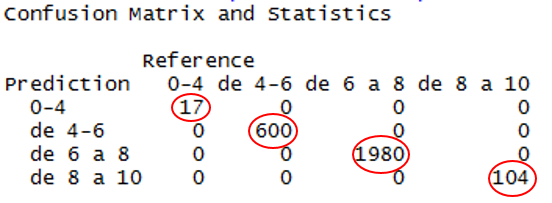

```r
RF_importance = randomForest::importance(rf)[order(randomForest::importance(rf)[,1], decreasing = TRUE), ]
knitr::kable(RF_importance)
```

|  | x |
| --- | --- |
| num_voted_users | 179.1631548 |
| duration | 98.1993168 |
| gross | 95.1481603 |
| budget | 93.7241996 |
| num_user_for_reviews | 88.7119701 |
| num_critic_for_reviews | 81.8097303 |
| cast_total_facebook_likes | 81.3728240 |
| title_year | 78.1429068 |
| movie_facebook_likes | 59.6798213 |
| Drama | 46.9617929 |
| Horror | 24.5720541 |
| aspect_ratio | 17.5361251 |
| Action | 16.1544228 |
| Comedy | 15.2107361 |
| Thriller | 12.4377365 |
| Fantasy | 11.8918100 |
| Crime | 11.0678566 |
| Adventure | 10.8126593 |
| Romance | 10.1820825 |
| Animation | 8.8632851 |
| Family | 7.6255613 |
| Mystery | 6.4858020 |
| Music | 5.2719970 |
| Sport | 3.9552722 |
| Biography | 3.8356726 |
| War | 2.4228446 |
| Western | 2.3940858 |
| History | 2.3859562 |
| Musical | 2.2071731 |
| Documentary | 2.0440810 |
| Short | 0.0124063 |
| Sci_Fi | 0.0000000 |
| Game_Show | 0.0000000 |
| Reality_TV | 0.0000000 |
| News | 0.0000000 |
| Film_Noir | 0.0000000 |

Verificamos que as variávei *Game_Show*, *Sci_Fi*, *Reality_TV*, *News* e *Film_Noir* não foram relevantes para o algoritmo do random forest.

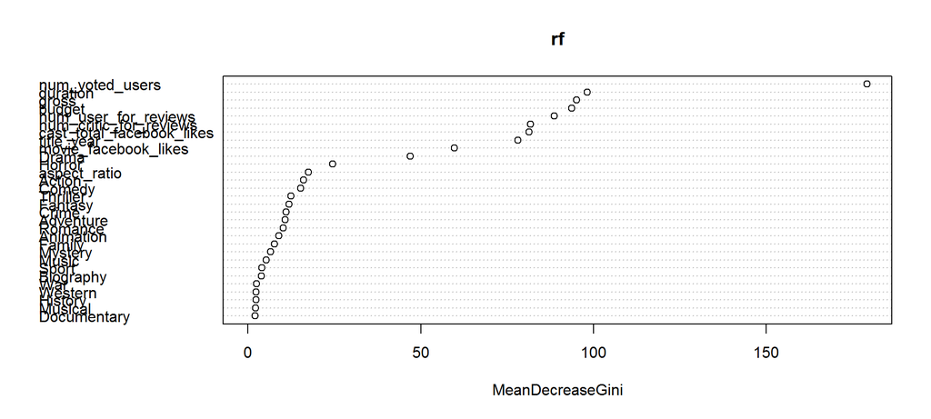

```r
randomForest::varImpPlot(rf)
```

**Taxa de Erro - Random Forest**

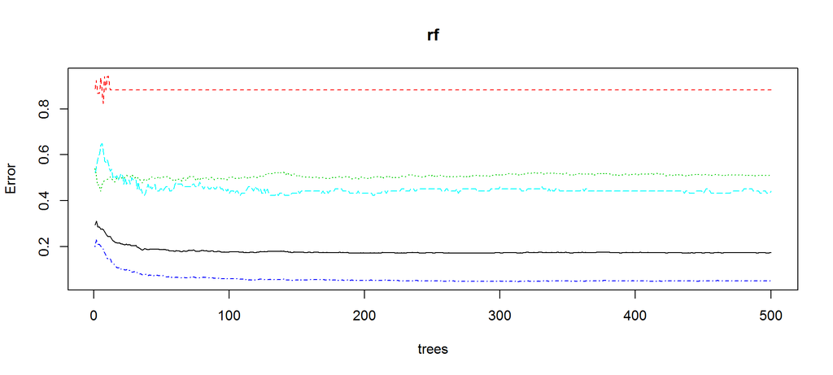

```r
plot(rf)
```

Observamos que, a partir do número de árvores geradas $ntrees > 100$ o erro OOB (Out of Bag) não pode ser melhorado.

**Ajustando e melhorando estimativas**

No passo a seguir, iremos remover as variáveis *Game_Show*, *Sci_Fi*, *Reality_TV*, *News*, *Short* e *Film_Noir* uma vez que estas não se mostraram importantes no algoritmo.

```r
train1 = train %>% select(-Sci_Fi, -Game_Show, -Reality_TV, -News, -Film_Noir, -Short)
test1 = test %>% select(-Sci_Fi, -Game_Show, -Reality_TV, -News, -Film_Noir, -Short)
```

Além disso, iremos alterar alguns parâmetros da função `randomForest` como o número de ntrees e mtry. Assim, repetimos o algoritmo do Random Forest, ainda usando a base treino.

```
## mtry = 5  OOB error = 17.99%
## Searching left ...
## mtry = 17    OOB error = 18.55%
## -0.0308642 0.05
## Searching right ...
## mtry = 1     OOB error = 26.69%
## -0.4835391 0.05
```

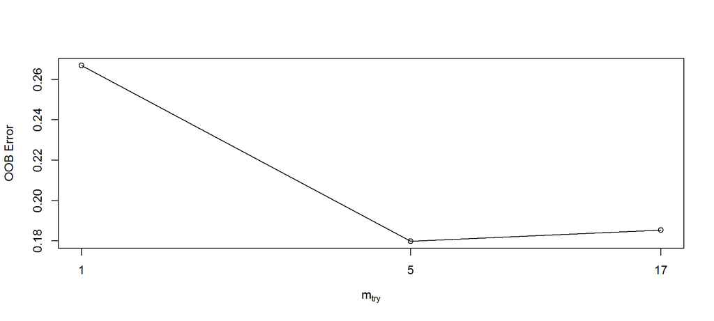

```r
# Tune mtry
x = as.data.frame(train1[,-31])
y = (as.factor(train1$WR_Grp))
t <- tuneRF(x = x, y = y,
       stepFactor = 0.3,
       plot = TRUE,
       ntreeTry = 100,
       trace = TRUE,
       improve = 0.05)
```

Aparentemente, 5 é um bom candidato ao valor de $m_{try}$

```r
#set.seed(093180)
set.seed(998451)
rf1 <- randomForest(WR_Grp~.,data=train1,
                    ntree = 100,
                    mtry = 5,
                    importance = TRUE,
                    proximity = TRUE)
rf1
```

```
##
## Call:
##  randomForest(formula = WR_Grp ~ ., data = train1, ntree = 100,      mtry = 5, importance = TRUE, proximity = TRUE)
##                Type of random forest: classification
##                      Number of trees: 100
## No. of variables tried at each split: 5
##
##         OOB estimate of  error rate: 17.7%
## Confusion matrix:
##           de 0 a 4 de 4 a 6 de 6 a 8 de 8 a 10 class.error
## de 0 a 4         2        6        9         0  0.88235294
## de 4 a 6         0      290      310         0  0.51666667
## de 6 a 8         0      102     1870         8  0.05555556
## de 8 a 10        0        0       43        61  0.41346154
```

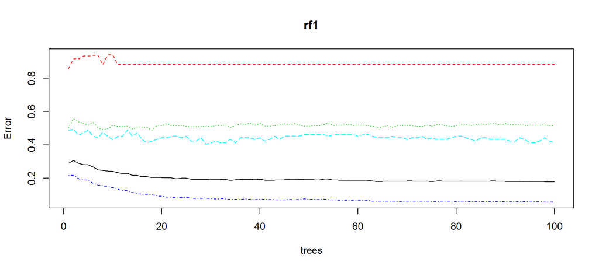

```r
RF_importance1 = randomForest::importance(rf1)[order(randomForest::importance(rf1)[,1], decreasing = TRUE), ]
plot(rf1)
```

```r
RF1 = data.frame(variables = rownames(RF_importance1), importance = RF_importance1[,6])
RF1 = RF1[order(RF1$importance, decreasing = TRUE),]
rownames(RF1) <- NULL

hc6 <- highchart() %>%
  hc_add_series(data = RF1$importance,
                type = "bar",
                name = "Importância",
                showInLegend = FALSE,
                tooltip = list(valueDecimals = 2, valuePrefix = "", valueSuffix = "")) %>%
  hc_yAxis(title = list(text = "Importância"),
           allowDecimals = TRUE, max = 200,
           labels = list(format = "{value}")) %>%
  hc_xAxis(title = list(text = "Fatores"),
           categories = RF1$variables,
           tickmarkPlacement = "on",
           opposite = FALSE) %>%
  hc_title(text = "Importância por fator - Random Forest",
           style = list(fontWeight = "bold")) %>%
  hc_subtitle(text = paste("")) %>%
      hc_tooltip(valueDecimals = 2,
                 pointFormat = "Importância: {point.y}")%>%
                 #pointFormat = "Variável: {point.x} <br> Importância: {point.y}")
      hc_credits(enabled = TRUE,
                 text = "Fonte: IMDB/KAGGLE. Elaboração: Ewerson Pimenta.",
                 style = list(fontSize = "10px")) %>%
  hc_exporting(enabled = TRUE, filename = "F4-missing-Pimenta")
#hc <- hc %>%
#  hc_add_theme(hc_theme_darkunica())
hc6
```

[interactive chart not shown]

**Predição e matriz de confusão - train data**

```r
library(caret)
p1 <- predict(rf1,train1)
head(p1)
```

```
##         1         2         3         4         5         6
##  de 6 a 8  de 6 a 8  de 6 a 8 de 8 a 10  de 6 a 8  de 6 a 8
## Levels: de 0 a 4 de 4 a 6 de 6 a 8 de 8 a 10
```

```r
head(train1$WR_Grp)
```

```
## [1] de 6 a 8  de 6 a 8  de 6 a 8  de 8 a 10 de 6 a 8  de 6 a 8
## Levels: de 0 a 4 de 4 a 6 de 6 a 8 de 8 a 10
```

```r
confusionMatrix(p1, train1$WR_Grp)
```

```
## Confusion Matrix and Statistics
##
##            Reference
## Prediction  de 0 a 4 de 4 a 6 de 6 a 8 de 8 a 10
##   de 0 a 4        17        0        0         0
##   de 4 a 6         0      600        0         0
##   de 6 a 8         0        0     1980         0
##   de 8 a 10        0        0        0       104
##
## Overall Statistics
##
##                Accuracy : 1
##                  95% CI : (0.9986, 1)
##     No Information Rate : 0.7331
##     P-Value [Acc > NIR] : < 2.2e-16
##
##                   Kappa : 1
##  Mcnemar's Test P-Value : NA
##
## Statistics by Class:
##
##                      Class: de 0 a 4 Class: de 4 a 6 Class: de 6 a 8
## Sensitivity                 1.000000          1.0000          1.0000
## Specificity                 1.000000          1.0000          1.0000
## Pos Pred Value              1.000000          1.0000          1.0000
## Neg Pred Value              1.000000          1.0000          1.0000
## Prevalence                  0.006294          0.2221          0.7331
## Detection Rate              0.006294          0.2221          0.7331
## Detection Prevalence        0.006294          0.2221          0.7331
## Balanced Accuracy           1.000000          1.0000          1.0000
##                      Class: de 8 a 10
## Sensitivity                    1.0000
## Specificity                    1.0000
## Pos Pred Value                 1.0000
## Neg Pred Value                 1.0000
## Prevalence                     0.0385
## Detection Rate                 0.0385
## Detection Prevalence           0.0385
## Balanced Accuracy              1.0000
```

**Predição e matriz de confusão - test data**

```r
p2 <- predict(rf1,test1)
head(p2)
```

```
##         1         2         3         4         5         6
##  de 6 a 8  de 6 a 8  de 6 a 8 de 8 a 10  de 6 a 8 de 8 a 10
## Levels: de 0 a 4 de 4 a 6 de 6 a 8 de 8 a 10
```

```r
head(test1$WR_Grp)
```

```
## [1] de 6 a 8 de 6 a 8 de 6 a 8 de 6 a 8 de 6 a 8 de 6 a 8
## Levels: de 0 a 4 de 4 a 6 de 6 a 8 de 8 a 10
```

```r
confusionMatrix(p2, test1$WR_Grp)
```

```
## Confusion Matrix and Statistics
##
##            Reference
## Prediction  de 0 a 4 de 4 a 6 de 6 a 8 de 8 a 10
##   de 0 a 4         1        0        0         0
##   de 4 a 6        10      132       40         0
##   de 6 a 8         2      106      770        25
##   de 8 a 10        0        0        7        21
##
## Overall Statistics
##
##                Accuracy : 0.8294
##                  95% CI : (0.806, 0.8511)
##     No Information Rate : 0.7334
##     P-Value [Acc > NIR] : 2.147e-14
##
##                   Kappa : 0.5385
##  Mcnemar's Test P-Value : NA
##
## Statistics by Class:
##
##                      Class: de 0 a 4 Class: de 4 a 6 Class: de 6 a 8
## Sensitivity                0.0769231          0.5546          0.9425
## Specificity                1.0000000          0.9429          0.5522
## Pos Pred Value             1.0000000          0.7253          0.8527
## Neg Pred Value             0.9892183          0.8863          0.7773
## Prevalence                 0.0116697          0.2136          0.7334
## Detection Rate             0.0008977          0.1185          0.6912
## Detection Prevalence       0.0008977          0.1634          0.8106
## Balanced Accuracy          0.5384615          0.7488          0.7473
##                      Class: de 8 a 10
## Sensitivity                   0.45652
## Specificity                   0.99345
## Pos Pred Value                0.75000
## Neg Pred Value                0.97698
## Prevalence                    0.04129
## Detection Rate                0.01885
## Detection Prevalence          0.02513
## Balanced Accuracy             0.72498
```

**Nº de nós nas árvores**

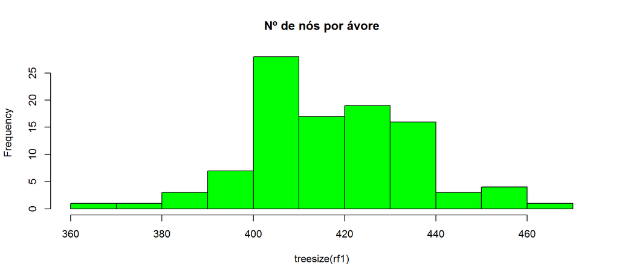

```r
hist(treesize(rf1),
     main = "Nº de nós por ávore",
     col = "green")
```

**Extração de uma única árvore** $Árvore \space n_{tree}=1$

```r
datatable(getTree(rf1, 1, labelVar = TRUE),
          options = list(searchin = TRUE, pageLength = 5))
```

|  | left daughter | right daughter | split var | split point | status | prediction |
| --- | --- | --- | --- | --- | --- | --- |
| 1 | 2 | 3 | Horror | 0.5 | 1 |  |
| 2 | 4 | 5 | cast_total_facebook_likes | 1265.5 | 1 |  |
| 3 | 6 | 7 | num_user_for_reviews | 501.5 | 1 |  |
| 4 | 8 | 9 | cast_total_facebook_likes | 615.5 | 1 |  |
| 5 | 10 | 11 | Drama | 0.5 | 1 |  |
| 6 | 12 | 13 | duration | 102.5 | 1 |  |
| 7 | 14 | 15 | Comedy | 0.5 | 1 |  |
| 8 | 16 | 17 | num_critic_for_reviews | 95.5 | 1 |  |
| 9 | 18 | 19 | Drama | 0.5 | 1 |  |
| 10 | 20 | 21 | movie_facebook_likes | 1500 | 1 |  |

[output cut: 811 more lines]

```r
remove(INFO)
```

$Árvore \space n_{tree}=100$

```r
datatable(getTree(rf1, 100, labelVar = TRUE),
          options = list(searchin = TRUE, pageLength = 5))
```

|  | left daughter | right daughter | split var | split point | status | prediction |
| --- | --- | --- | --- | --- | --- | --- |
| 1 | 2 | 3 | Action | 0.5 | 1 |  |
| 2 | 4 | 5 | cast_total_facebook_likes | 2131.5 | 1 |  |
| 3 | 6 | 7 | num_voted_users | 104792 | 1 |  |
| 4 | 8 | 9 | Thriller | 0.5 | 1 |  |
| 5 | 10 | 11 | Comedy | 0.5 | 1 |  |
| 6 | 12 | 13 | duration | 117.5 | 1 |  |
| 7 | 14 | 15 | duration | 157 | 1 |  |
| 8 | 16 | 17 | duration | 96.5 | 1 |  |
| 9 | 18 | 19 | num_voted_users | 42524 | 1 |  |
| 10 | 20 | 21 | aspect_ratio | 1.515 | 1 |  |

[output cut: 853 more lines]

```r
remove(INFO)
```

**Gráfico de escala multidimensional da matriz de proximidade**

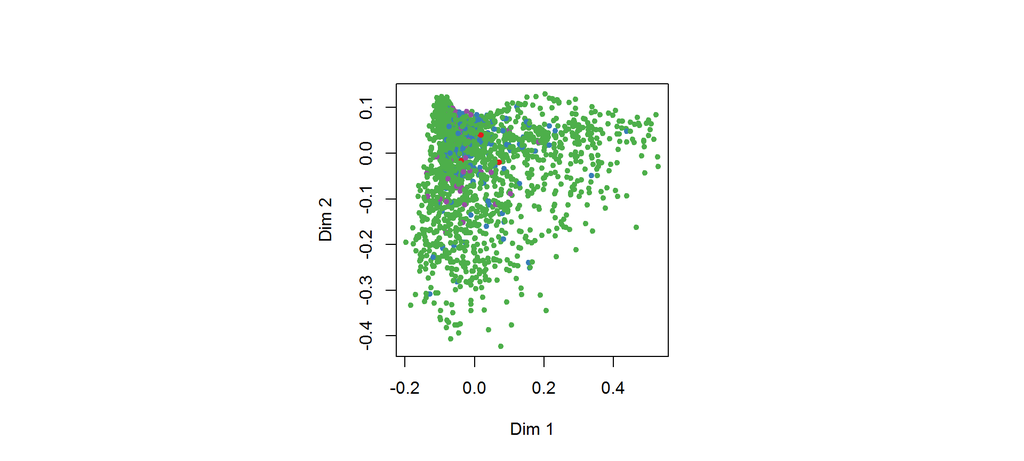

```r
MDSplot(rf1, train1$WR_Grp, pch=20)
```

Plot do modelo `rpart` - *Recursive Partitioning and Regression Trees* - personalizando automaticamente a partir do gráfico para o tipo de resposta do modelo.

[figure not shown]

```r
rp <- rpart::rpart(formula = WR_Grp~.,data=test1)
#rpart::plotcp(rp)
rpart.plot(rp)
```

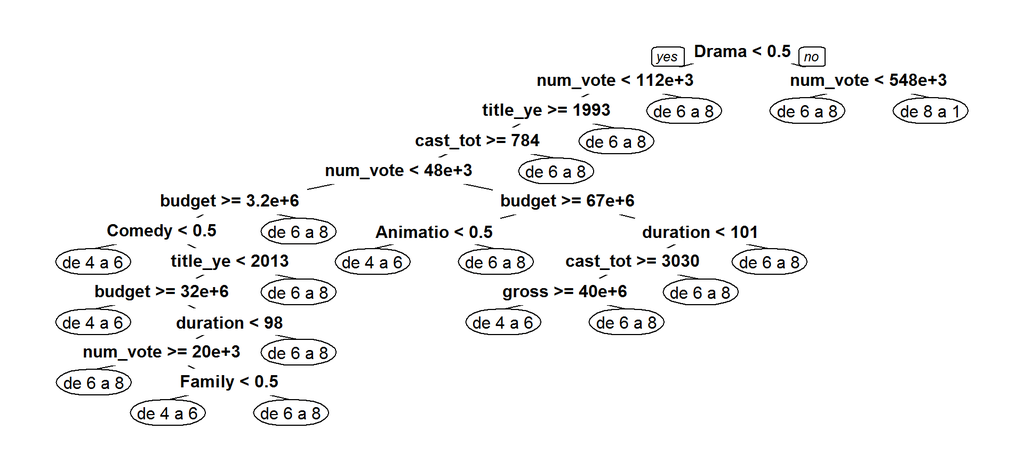

```r
rpart.plot.version1(rp)
```

Tempo de execução

```r
proc.time() -ptm
```

```
##    user  system elapsed
##   43.39    1.82   47.58
```